# Module 1 - Quiz

Sasha Ajay Malkani

2025-11-11

## Question 1

Reproducibility is defined informally as the ability to recompute data analytic results conditional on an observed data set and knowledge of the statistical pipeline used to calculate them [Peng 2011](https://www.science.org/doi/abs/10.1126/science.1213847), Science. Replicability of a study is the chance that a new experiment targeting the same scientific question will produce a consistent result [Asendorpf 2013 European Journal of Personality](https://onlinelibrary.wiley.com/doi/abs/10.1002/per.1919).

Susan asks Joe for his data shared according to the data sharing plan discussed in the lectures. Which of the following are reasons the study may be reproducible, but not replicable?

- Joe doesn’t make the raw data accessible so Susan can’t re-run his code.
- The code for processing the data is written as a collection of R scripts and not R markdown files, so it is difficult to understand what each step does.
- The processed data alone don’t give enough information to replicate the entire study.
- **The identified effect can be reproduced from Joe’s code and data, but may be due only to random variation and not appear in future studies.**

## Question 2

Put the following code chunk at the top of an R markdown document called test.Rmd but set eval=TRUE

### 2. A. Setup

```r
knitr::opts_chunk$set(cache=TRUE)
```

Then create the following code chunks

### 2. B. Plot

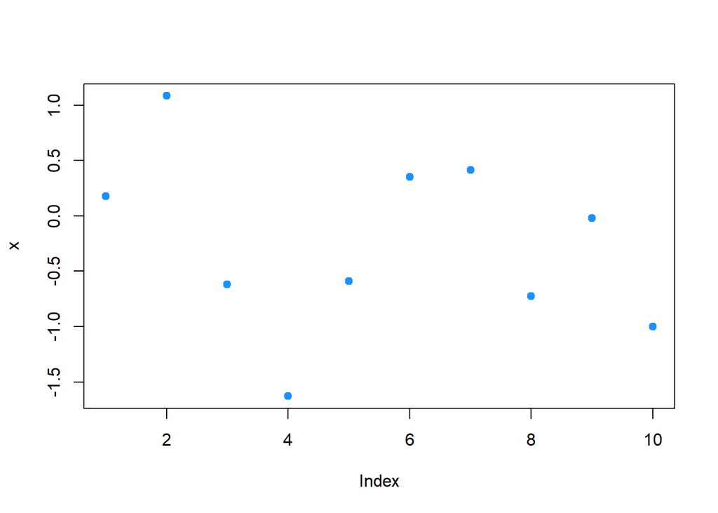

```r
x = rnorm(10)
plot(x,pch=19,col="dodgerblue")
```

### 2. C. Table

```r
y = rbinom(20,size=1,prob=0.5)
table(y)
```

```
## y
##  0  1
##  7 13
```

- The table is random each time you knit the document, but the plot is always the same after you knit it the first time.
- The plot and table are random every time you knit the document, except for the last time.
- **The plot is random the first time you knit the document. It is identical to the first time the second time you knit the document. After removing the folders test_cache and test_files they generate new random versions.**
- The plot and table are random the first time you knit the document. They are identical the second time you knit the document. After removing the folders test_cache and test_files they are still identical.

## Question 3

Create a summarizedExperiment object with the following code

### 3. A. Creating Summarized Experiment Object

```r
# BiocManager::install(c("SummarizedExperiment"))
library(Biobase)
library(GenomicRanges)
library(SummarizedExperiment)
data(sample.ExpressionSet, package = "Biobase")
se = makeSummarizedExperimentFromExpressionSet(sample.ExpressionSet)
```

### 3. B. How do you access the genomic data for this object?

```r
genomic_table = assay(se)
head(genomic_table)
```

```
##                        A         B        C        D        E       F        G
## AFFX-MurIL2_at  192.7420  85.75330 176.7570 135.5750 64.49390 76.3569 160.5050
## AFFX-MurIL10_at  97.1370 126.19600  77.9216  93.3713 24.39860 85.5088  98.9086
## AFFX-MurIL4_at   45.8192   8.83135  33.0632  28.7072  5.94492 28.2925  30.9694
## AFFX-MurFAS_at   22.5445   3.60093  14.6883  12.3397 36.86630 11.2568  23.0034
## AFFX-BioB-5_at   96.7875  30.43800  46.1271  70.9319 56.17440 42.6756  86.5156
## AFFX-BioB-M_at   89.0730  25.84610  57.2033  69.9766 49.58220 26.1262  75.0083
##                       H       I         J        K       L       M       N
## AFFX-MurIL2_at  65.9631 56.9039 135.60800 63.44320 78.2126 83.0943 89.3372
## AFFX-MurIL10_at 81.6932 97.8015  90.48380 70.57330 94.5418 75.3455 68.5827
## AFFX-MurIL4_at  14.7923 14.2399  34.48740 20.35210 14.1554 20.6251 15.9231
## AFFX-MurFAS_at  16.2134 12.0375   4.54978  8.51782 27.2852 10.1616 20.2488
## AFFX-BioB-5_at  30.7927 19.7183  46.35200 39.13260 41.7698 80.2197 36.4903
## AFFX-BioB-M_at  42.3352 41.1207  91.53070 39.91360 49.8397 63.4794 24.7007
##                       O       P        Q        R         S       T         U
## AFFX-MurIL2_at  91.0615 95.9377 179.8450 152.4670 180.83400 85.4146 157.98900
## AFFX-MurIL10_at 87.4050 84.4581  87.6806 108.0320 134.26300 91.4031  -8.68811
## AFFX-MurIL4_at  20.1579 27.8139  32.7911  33.5292  19.81720 20.4190  26.87200
## AFFX-MurFAS_at  15.7849 14.3276  15.9488  14.6753  -7.91911 12.8875  11.91860
## AFFX-BioB-5_at  36.4021 35.3054  58.6239 114.0620  93.44020 22.5168  48.64620
## AFFX-BioB-M_at  47.4641 47.3578  58.1331 104.1220 115.83100 58.1224  73.42210
##                        V       W         X       Y         Z
## AFFX-MurIL2_at  146.8000 93.8829 103.85500 64.4340 175.61500
## AFFX-MurIL10_at  85.0212 79.2998  71.65520 64.2369  78.70680
## AFFX-MurIL4_at   31.1488 22.3420  19.01350 12.1686  17.37800
## AFFX-MurFAS_at   12.8324 11.1390   7.55564 19.9849   8.96849
## AFFX-BioB-5_at   90.2215 42.0053  57.57380 44.8216  61.70440
## AFFX-BioB-M_at   64.6066 40.3068  41.82090 46.1087  49.41220
```

### 3. C. How do you access the phenotype table?

```r
phenotype_table = colData(se)
phenotype_table
```

```
## DataFrame with 26 rows and 3 columns
##          sex     type     score
##     <factor> <factor> <numeric>
## A     Female  Control      0.75
## B     Male    Case         0.40
## C     Male    Control      0.73
## D     Male    Case         0.42
## E     Female  Case         0.93
## ...      ...      ...       ...
## V     Female  Control      0.77
## W     Male    Control      0.27
## X     Male    Control      0.98
## Y     Female  Case         0.94
## Z     Female  Case         0.32
```

### 3. D. How do you access the feature data?

```r
feature_data = rowData(se)
feature_data
```

```
## DataFrame with 500 rows and 0 columns
```

### 3. E. What is the unique additional information provided by rowRanges(se)?

```r
additional_info = rowRanges(se)
head(additional_info)
```

```
## GRangesList object of length 6:
## $`AFFX-MurIL2_at`
## GRanges object with 0 ranges and 0 metadata columns:
##    seqnames    ranges strand
##       <Rle> <IRanges>  <Rle>
##   -------
##   seqinfo: no sequences
##
## $`AFFX-MurIL10_at`
## GRanges object with 0 ranges and 0 metadata columns:
##    seqnames    ranges strand
##       <Rle> <IRanges>  <Rle>
##   -------
##   seqinfo: no sequences
##
## $`AFFX-MurIL4_at`
## GRanges object with 0 ranges and 0 metadata columns:
##    seqnames    ranges strand
##       <Rle> <IRanges>  <Rle>
##   -------
##   seqinfo: no sequences
##
## ...
## <3 more elements>
```

Look up the help files for summarizedExperiment with the code?summarizedExperiment. How do you access the genomic data for this object? How do you access the phenotype table? How do you access the feature data? What is the unique additional information provided by rowRanges(se)?

- **Get the genomic table with *assay(se)* , get the phenotype table with *colData(se)*, get the feature data with *rowData(se)* . *rowRanges(se)* gives information on the genomic location and structure of the measured features.**
- Get the genomic table with assay(se), get the phenotype table with colData(se), get the feature data with rowRanges(se). rowRanges(se) gives the range of possible values for the expression data.
- Get the genomic table with assay(se), get the phenotype table with pData(se), get the feature data with rowData(se).rowRanges(se) gives information on the genomic location and structure of the measured features.
- Get the genomic table with assay(se), get the phenotype table with colData(se), get the feature data with rowData(se).rowRanges(se) gives the range of possible values for the expression data.

## Question 4

Suppose that you have measured ChIP-Seq data from 10 healthy individuals and 10 metastatic cancer patients. For each individual you split the sample into two identical sub-samples and perform the ChIP-Seq experiment on each sub-sample. How can you measure **(a) biological variability, (b) technical variability and** **(c) phenotype variability?**

- 1. **By looking at variation across samples from 10 different healthy individuals**
  2. **By looking at variability between the measurements on the two sub-samples** **from the same sample and**
  3. **by comparing the average measurements on the healthy individuals to the** **measurements on the individuals with cancer.**
- 1. By looking at variation across samples from 10 different individuals with cancer
  2. By comparing the average variability in the cancer and normal individuals
  3. By comparing the average measurements on the healthy individuals to the measurements on the individuals with cancer.
- 1. By looking at variation across replicate sub-samples within the normal individuals
  2. By looking at variation across samples from 10 different healthy individuals
  3. By comparing the average measurements on the healthy individuals to the measurements on the individuals with cancer.
- 1. & (b) By looking at variation across samples from 10 different healthy individuals.
  2. by comparing the average measurements on the healthy individuals to the measurements on the individuals with cancer.

## Question 5

Load the Bottomly and the Bodymap data sets with the following code:

### 5. A. Loading Biobase Library

```r
library(Biobase)
```

### 5. B. Bottomly Data Set

```r
con =url("http://bowtie-bio.sourceforge.net/recount/ExpressionSets/bottomly_eset.RData")
load(file=con)
close(con)
bot = bottomly.eset
pdata_bot=pData(bot)
pdata_bot
```

```
##           sample.id num.tech.reps   strain experiment.number lane.number
## SRX033480 SRX033480             1 C57BL/6J                 6           1
## SRX033488 SRX033488             1 C57BL/6J                 7           1
## SRX033481 SRX033481             1 C57BL/6J                 6           2
## SRX033489 SRX033489             1 C57BL/6J                 7           2
## SRX033482 SRX033482             1 C57BL/6J                 6           3
## SRX033490 SRX033490             1 C57BL/6J                 7           3
## SRX033483 SRX033483             1 C57BL/6J                 6           5
## SRX033476 SRX033476             1 C57BL/6J                 4           6
## SRX033478 SRX033478             1 C57BL/6J                 4           7
## SRX033479 SRX033479             1 C57BL/6J                 4           8
## SRX033472 SRX033472             1   DBA/2J                 4           1
## SRX033473 SRX033473             1   DBA/2J                 4           2
## SRX033474 SRX033474             1   DBA/2J                 4           3
## SRX033475 SRX033475             1   DBA/2J                 4           5
## SRX033491 SRX033491             1   DBA/2J                 7           5
## SRX033484 SRX033484             1   DBA/2J                 6           6
## SRX033492 SRX033492             1   DBA/2J                 7           6
## SRX033485 SRX033485             1   DBA/2J                 6           7
## SRX033493 SRX033493             1   DBA/2J                 7           7
## SRX033486 SRX033486             1   DBA/2J                 6           8
## SRX033494 SRX033494             1   DBA/2J                 7           8
```

### 5. C. Body Map Data Set

```r
con =url("http://bowtie-bio.sourceforge.net/recount/ExpressionSets/bodymap_eset.RData")
load(file=con)
close(con)
bm = bodymap.eset
pdata_bm=pData(bm)
pdata_bm
```

```
##           sample.id num.tech.reps      tissue.type gender age             race
## ERS025098 ERS025098             2          adipose      F  73        caucasian
## ERS025092 ERS025092             2          adrenal      M  60        caucasian
## ERS025085 ERS025085             2            brain      F  77        caucasian
## ERS025088 ERS025088             2           breast      F  29        caucasian
## ERS025089 ERS025089             2            colon      F  68        caucasian
## ERS025082 ERS025082             2            heart      M  77        caucasian
## ERS025081 ERS025081             2           kidney      F  60        caucasian
## ERS025096 ERS025096             2            liver      M  37        caucasian
## ERS025099 ERS025099             2             lung      M  65        caucasian
## ERS025086 ERS025086             2        lymphnode      F  86        caucasian
## ERS025084 ERS025084             6          mixture   <NA>  NA        caucasian
## ERS025087 ERS025087             5          mixture   <NA>  NA        caucasian
## ERS025093 ERS025093             5          mixture   <NA>  NA        caucasian
## ERS025083 ERS025083             2            ovary      F  47 african_american
## ERS025095 ERS025095             2         prostate      M  73        caucasian
## ERS025097 ERS025097             2  skeletal_muscle      M  77        caucasian
## ERS025094 ERS025094             2           testes      M  19        caucasian
## ERS025090 ERS025090             2          thyroid      F  60        caucasian
## ERS025091 ERS025091             2 white_blood_cell      M  58        caucasian
```

Just considering the phenotype data what are some reasons that the Bottomly data set is likely a better experimental design than the Bodymap data? Imagine the question of interest in the Bottomly data is to compare strains and in the Bodymap data it is to compare tissues.

- **The Bottomly data has biological replicates for each group but the Bodymap** **data does not.**
- The Bodymap data has measured more levels of the outcome of interest (tissues) than the Bottomly data has measured (strains).
- The Bottomly data set does not measure the age of the mice.
- Most of the tissues in the Bodymap data have a consistent number of technical replicates (2).

**The covariates in the Bottomly data set (experiment number, lane number) are balanced with respect to strain.** **The covariates in the Bodymap data set (gender, age, number of technical replicates) are not balanced with** **respect to tissue.**

## Question 6

What are some reasons why this plot is not useful for comparing the number of technical replicates by tissue (you may need to install the plotrix package).

### 6. A. Loading Biobase library

```r
# library(Biobase)
```

### 6. B. Loading Body Map Data Set

```r
con =url("http://bowtie-bio.sourceforge.net/recount/ExpressionSets/bodymap_eset.RData")
load(file=con)
close(con)
bm = bodymap.eset
pdata_bm=pData(bm)
pdata_bm
```

```
##           sample.id num.tech.reps      tissue.type gender age             race
## ERS025098 ERS025098             2          adipose      F  73        caucasian
## ERS025092 ERS025092             2          adrenal      M  60        caucasian
## ERS025085 ERS025085             2            brain      F  77        caucasian
## ERS025088 ERS025088             2           breast      F  29        caucasian
## ERS025089 ERS025089             2            colon      F  68        caucasian
## ERS025082 ERS025082             2            heart      M  77        caucasian
## ERS025081 ERS025081             2           kidney      F  60        caucasian
## ERS025096 ERS025096             2            liver      M  37        caucasian
## ERS025099 ERS025099             2             lung      M  65        caucasian
## ERS025086 ERS025086             2        lymphnode      F  86        caucasian
## ERS025084 ERS025084             6          mixture   <NA>  NA        caucasian
## ERS025087 ERS025087             5          mixture   <NA>  NA        caucasian
## ERS025093 ERS025093             5          mixture   <NA>  NA        caucasian
## ERS025083 ERS025083             2            ovary      F  47 african_american
## ERS025095 ERS025095             2         prostate      M  73        caucasian
## ERS025097 ERS025097             2  skeletal_muscle      M  77        caucasian
## ERS025094 ERS025094             2           testes      M  19        caucasian
## ERS025090 ERS025090             2          thyroid      F  60        caucasian
## ERS025091 ERS025091             2 white_blood_cell      M  58        caucasian
```

### 6. C. Plotting 3D Pie Chart

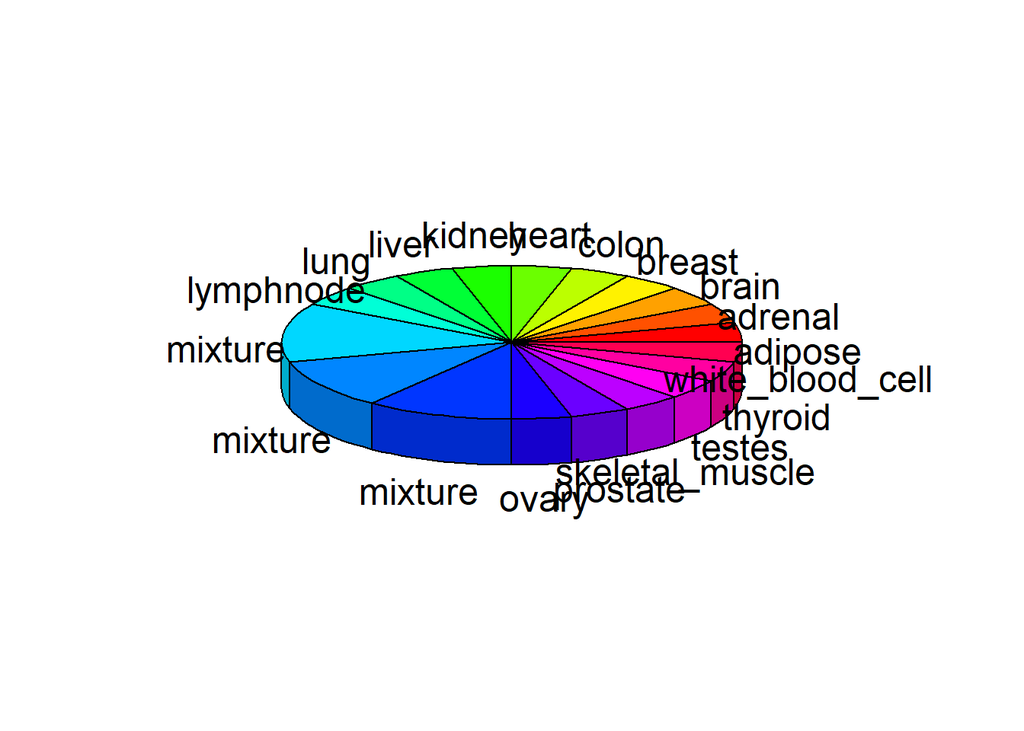

```r
# install.packages('plotrix')
library(plotrix)
pie3D(pdata_bm$num.tech.reps,labels=pdata_bm$tissue.type)
```

- **The plot is in 3-d so it makes it hard to compare the angles.**
- There are a large number of data points underlying each wedge and you can’t see them.
- The plot would be much easier to see if the pie chart were rotated by 90 degrees from its current position.
- There is nothing wrong with the plot, it accurately shows how many replicates of each type there are.

**The “mixture” category is split across multiple wedges.**

## Question 7

### 7. A. Load the Bottomly data:

```r
con =url("http://bowtie-bio.sourceforge.net/recount/ExpressionSets/bottomly_eset.RData")
load(file=con)
close(con)
ls()
```

```
##  [1] "additional_info"      "bm"                   "bodymap.eset"
##  [4] "bot"                  "bottomly.eset"        "con"
##  [7] "feature_data"         "genomic_table"        "pdata_bm"
## [10] "pdata_bot"            "phenotype_table"      "sample.ExpressionSet"
## [13] "se"                   "x"                    "y"
```

```r
bot = bottomly.eset
bot
```

```
## ExpressionSet (storageMode: lockedEnvironment)
## assayData: 36536 features, 21 samples
##   element names: exprs
## protocolData: none
## phenoData
##   sampleNames: SRX033480 SRX033488 ... SRX033494 (21 total)
##   varLabels: sample.id num.tech.reps ... lane.number (5 total)
##   varMetadata: labelDescription
## featureData
##   featureNames: ENSMUSG00000000001 ENSMUSG00000000003 ...
##     ENSMUSG00000090268 (36536 total)
##   fvarLabels: gene
##   fvarMetadata: labelDescription
## experimentData: use 'experimentData(object)'
## Annotation:
```

```r
pdata_bot=pData(bot)
head(pdata_bot)
```

```
##           sample.id num.tech.reps   strain experiment.number lane.number
## SRX033480 SRX033480             1 C57BL/6J                 6           1
## SRX033488 SRX033488             1 C57BL/6J                 7           1
## SRX033481 SRX033481             1 C57BL/6J                 6           2
## SRX033489 SRX033489             1 C57BL/6J                 7           2
## SRX033482 SRX033482             1 C57BL/6J                 6           3
## SRX033490 SRX033490             1 C57BL/6J                 7           3
```

```r
fdata_bot = featureData(bot)
head(fdata_bot)
```

```
## An object of class 'AnnotatedDataFrame'
##   featureNames: ENSMUSG00000000001 ENSMUSG00000000003 ...
##     ENSMUSG00000000049 (6 total)
##   varLabels: gene
##   varMetadata: labelDescription
```

```r
edata = exprs(bot)
head(edata)
```

```
##                    SRX033480 SRX033488 SRX033481 SRX033489 SRX033482 SRX033490
## ENSMUSG00000000001       369       744       287       769       348       803
## ENSMUSG00000000003         0         0         0         0         0         0
## ENSMUSG00000000028         0         1         0         1         1         1
## ENSMUSG00000000031         0         0         0         0         0         0
## ENSMUSG00000000037         0         1         1         5         0         4
## ENSMUSG00000000049         0         1         0         1         0         0
##                    SRX033483 SRX033476 SRX033478 SRX033479 SRX033472 SRX033473
## ENSMUSG00000000001       433       469       585       321       301       461
## ENSMUSG00000000003         0         0         0         0         0         0
## ENSMUSG00000000028         0         7         6         1         1         1
## ENSMUSG00000000031         0         0         0         0         0         0
## ENSMUSG00000000037         0         0         0         0         4         1
## ENSMUSG00000000049         0         0         0         0         0         0
##                    SRX033474 SRX033475 SRX033491 SRX033484 SRX033492 SRX033485
## ENSMUSG00000000001       309       374       781       555       820       294
## ENSMUSG00000000003         0         0         0         0         0         0
## ENSMUSG00000000028         1         1         1         2         1         1
## ENSMUSG00000000031         0         0         0         0         0         0
## ENSMUSG00000000037         1         0         1         2         1         1
## ENSMUSG00000000049         0         0         0         0         0         0
##                    SRX033493 SRX033486 SRX033494
## ENSMUSG00000000001       758       419       857
## ENSMUSG00000000003         0         0         0
## ENSMUSG00000000028         4         1         5
## ENSMUSG00000000031         0         0         0
## ENSMUSG00000000037         1         1         2
## ENSMUSG00000000049         0         0         0
```

Which of the following code chunks will make a heatmap of the 500 most highly expressed genes (as defined by total count), without re-ordering due to clustering? Are the highly expressed samples next to each other in sample order?

### 7. B. **Code Chunk 1**

[figure not shown]

```r
row_sums = rowSums(edata)
edata = edata[order(-row_sums),]
index = 1:500
heatmap(edata[index,],Rowv=NA,Colv=NA)
```

Yes they are

7. C. Code Chunk 2

```r
# row_sums = rowSums(edata)
# index = which(rank(row_sums) < 500 )
# heatmap(edata[index,],Colv=NA)
```

The highly expressed samples are not next to each other.

7. D. Code Chunk 3

```r
# row_sums = rowSums(edata)
# edata = edata[order(row_sums),]
# index = which(rank(-row_sums) < 500 )
# heatmap(edata[index,],Rowv=NA,Colv=NA)
```

No they are not next to each other.

7. E. Code Chunk 4

```r
# row_sums = rowSums(edata)
# index = which(rank(-row_sums) < 500 )
# heatmap(edata[index,],Rowv=NA,Colv=NA)
```

## Question 8

Load the Bodymap data using the following code:

### 8. A. Loading Body map data

```r
con =url("http://bowtie-bio.sourceforge.net/recount/ExpressionSets/bodymap_eset.RData")
load(file=con)
close(con)
bm = bodymap.eset
pdata = pData(bm)
edata = exprs(bm)
head(edata)
```

```
##                 ERS025098 ERS025092 ERS025085 ERS025088 ERS025089 ERS025082
## ENSG00000000003      1354       216       215       924       725       125
## ENSG00000000005       712       134         4      1495       119        20
## ENSG00000000419       450       547       516       529       808       680
## ENSG00000000457       188       368       196       386       156       259
## ENSG00000000460        66        29         1        26        11         9
## ENSG00000000938       104        79         7        29         0         3
##                 ERS025081 ERS025096 ERS025099 ERS025086 ERS025084 ERS025087
## ENSG00000000003       796      1954       815       249      4614      6548
## ENSG00000000005         7         0         0        16       975       923
## ENSG00000000419       744       369       636       486      1200      2823
## ENSG00000000457       436       288       187       553      1543      1194
## ENSG00000000460        25        42        12        22       213        80
## ENSG00000000938         1        20       243        41       166       265
##                 ERS025093 ERS025083 ERS025095 ERS025097 ERS025094 ERS025090
## ENSG00000000003      5030      1450       781        69      1888       983
## ENSG00000000005       696        15        24         0        20         4
## ENSG00000000419      2159       933       870       621      1026      1185
## ENSG00000000457       876       655       862       242       569       609
## ENSG00000000460        57        13        78        17       351        46
## ENSG00000000938       211        10        11         0         0        22
##                 ERS025091
## ENSG00000000003         3
## ENSG00000000005         0
## ENSG00000000419       765
## ENSG00000000457       782
## ENSG00000000460        73
## ENSG00000000938      1508
```

## 8. B. MA or Bland-Altman plot

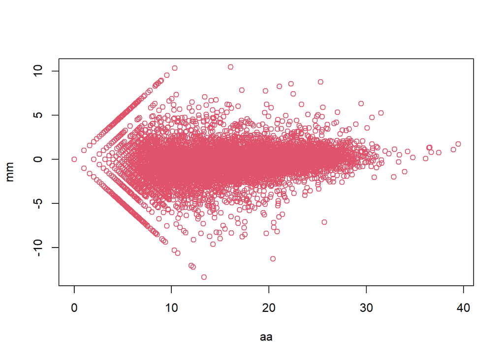

```r
mm = log2(edata[,1]+1) - log2(edata[,2]+1)
aa = log2(edata[,1]+1) + log2(edata[,2]+1)
plot(aa,mm,col=2)
```

## 8. C. MA or Bland-Altman plot (using DESeq2 package)

```r
library(DESeq2)
edata_log = rlog(edata + 1)
```

```
## -- note: fitType='parametric', but the dispersion trend was not well captured by the
##    function: y = a/x + b, and a local regression fit was automatically substituted.
##    specify fitType='local' or 'mean' to avoid this message next time.
```

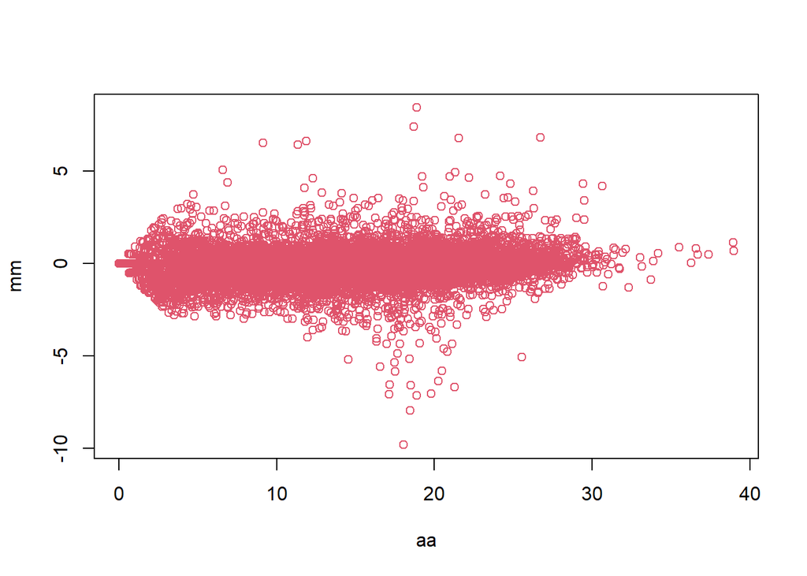

```r
mm = edata_log[,1] - edata_log[,2]
aa = edata_log[,1] + edata_log[,2]
plot(aa,mm,col=2)
```

Make an MA-plot of the first sample versus the second sample using the log2 transform (hint: you may have to add 1 first) and the rlog transform from the DESeq2 package. How are the two MA-plots different? Which kind of genes appear most different in each plot?

- The plots are very different as the log2 plot seems to shrink low abundance genes more and the rlog plot seems to shrink high abundance genes more. The genes in the middle of the distribution show the biggest differences.
- **The plots look pretty similar, but there are two strong diagonal stripes** **(corresponding to the zero count genes) in the log2 plot. In both cases,** **the genes in the middle of the expression distribution show the biggest** **differences, but the low abundance genes seem to show smaller differences** **with the rlog transform.**
- The plots look pretty similar, but there are two strong diagonal stripes (corresponding to the zero count genes) in the rlog plot. In both cases, the genes in the middle of the expression distribution show the biggest differences, but the low abundance genes seem to show smaller differences with the log2 transform.
- The plots are nearly identical. Both transforms seem to deal with the low abundance genes, including the zero genes the same way. The high-abundance genes show the most differences.

## Question 9

### 9. A. Load the Montgomery and Pickrell eSet

Cluster the data in three ways:

- With no changes to the data
- After filtering all genes with rowMeans less than 100
- After taking the log2 transform of the data without filtering

Color the samples by which study they came from (Hint: consider using the function myplclust.R in the package rafalib available from CRAN and looking at the argument lab.col.) How do the methods compare in terms of how well they cluster the data by study? Why do you think that is?

### 9. B. With no changes to the data

```r
# dist1 = dist(t(edata))
# hclust1 = hclust(dist1)
# par(mar=c(0, 4, 4, 2))
# plot(hclust1, hang = -1, main="origin", labels=FALSE)
```

### 9. C. After filtering all genes with rowMeans less than 100

```r
# low_genes = rowMeans(edata) < 100
# filter_edata = filter(edata, !low_genes)
# f_dist1 = dist(t(filter_edata))
# f_hclust1 = hclust(f_dist1)
# par(mar=c(0, 4, 4, 2))
# plot(f_hclust1, hang = -1, main="remove low expression", labels=FALSE)
```

### 9. D. After taking the log2 transform of the data without filtering

```r
# log_edata = log2(edata + 1)
# l_dist1 = dist(t(log_edata))
# l_hclust1 = hclust(l_dist1)
# par(mar=c(0, 4, 4, 2))
# plot(l_hclust1, hang=-1, main="perform log2 transform", labels=FALSE)
```

- Clustering with or without filtering is about the same. Clustering after the log2 transform shows better clustering with respect to the study variable. The likely reason is that the highly skewed distribution doesn’t match the Euclidean distance metric being used in the clustering example.
- Clustering is identical with all three approaches and they show equal clustering. The distance is an average over all the dimensions so it doesn’t change.
- Clustering with or without log2 transform is about the same. Clustering after filtering shows better clustering with respect to the study variable. The reason is that it is just the lowly expressed genes that make the distance hard to calculate.
- **Clustering with or without log2 transform is about the same. Clustering after** **filtering shows better clustering with respect to the study variable. The reason** **is that the lowly expressed genes have some extreme outliers that skew the calculation.**

## Question 10

### 10. A. Loading Montpick data set

```r
con =url("http://bowtie-bio.sourceforge.net/recount/ExpressionSets/montpick_eset.RData")
load(file=con)
close(con)
mp = montpick.eset
pdata=pData(mp)
edata=as.data.frame(exprs(mp))
fdata = fData(mp)
```

Cluster the samples using k-means clustering after applying the log2 transform (be sure to add 1). Set a seed for reproducible results (use set.seed(1235)). If you choose two clusters, do you get the same two clusters as you get if you use the cutree function to cluster the samples into two groups? Which cluster matches most closely to the study labels?

### 10. B. Log Transform

```r
edata = log2(edata + 1)
```

### 10. C. Perform k-means clustering - two clusters

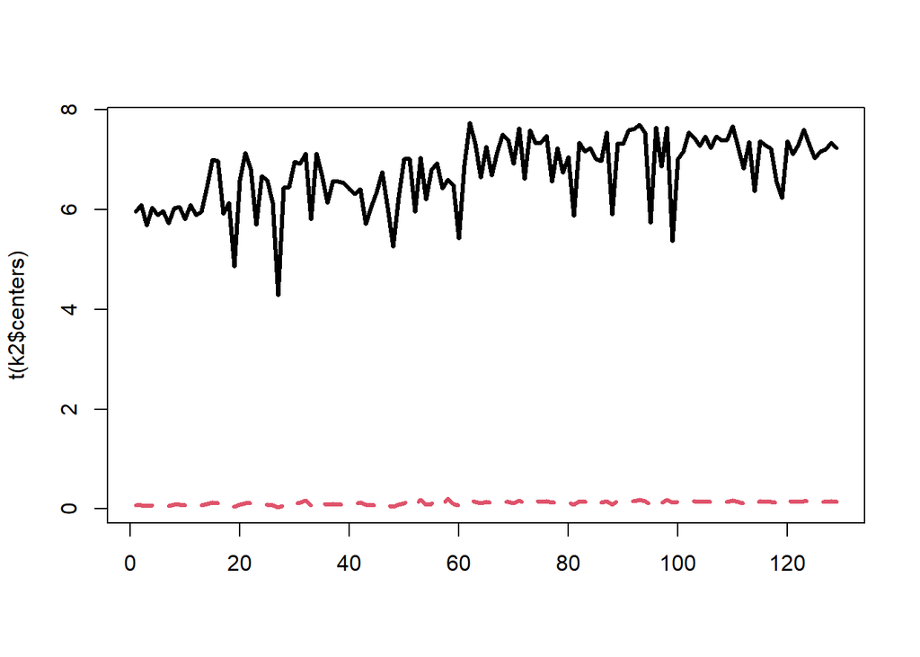

```r
set.seed(1235)
k2 = kmeans(edata,centers=2)
matplot(t(k2$centers),col=1:2,type="l",lwd=3)
```

### 10. D. Hierarchicial Clustering

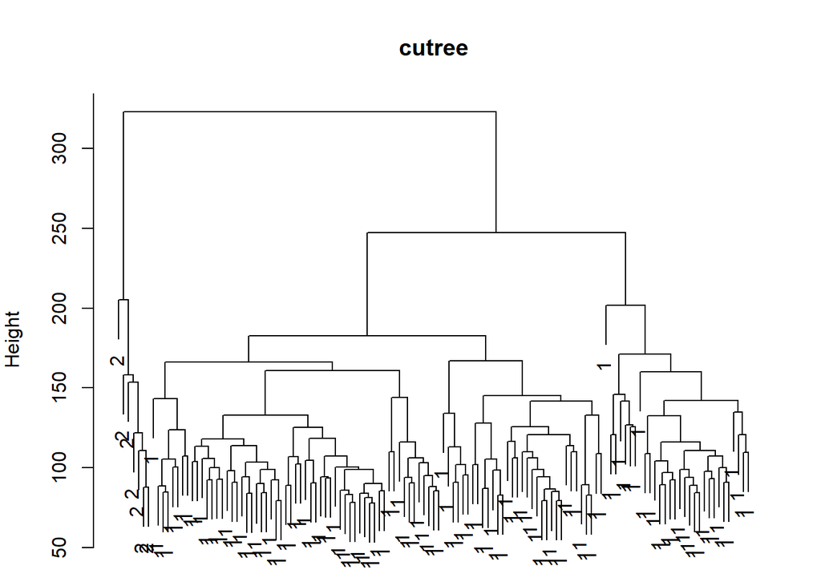

```r
dist1 = dist(t(edata))
hclust1 = hclust(dist1)
tree = cutree(hclust1, 2)
par(mar=c(0, 4, 4, 2))
plot(hclust1, tree, main="cutree")
```

- They produce the same answers and match the study variable equally well.
- They produce different clustering’s with hierarchical clustering more closely matching the study variable. K-means clustering is too random to pick up the study difference.
- They produce different answers, with k-means clustering giving a much more unbalanced clustering. The hierarchical clustering matches study better.
- **They produce different answers, with hierarchical clustering giving a much** **more unbalanced clustering. The k-means clustering matches study better.**

```r
Sys.Date()
```

```
## [1] "2025-11-26"
```